# R Notebook

# 0.0 Imports

```r
renv::restore()
```

```
It looks like you've called renv::restore() in a project that hasn't been activated yet
How would you like to proceed?

1: Activate the project and use the project library.
2: Do not activate the project and use the current library paths.
3: Cancel and resolve the situation another way.
```

```r
1
```

```
Restarting R session...
```

```r
library(tidyverse)
library(palmerpenguins)
library(ggthemes)
```

```r
df0 <- data.frame(penguins)
```

```r
#1

dim(df0)
```

```
[1] 344   8
```

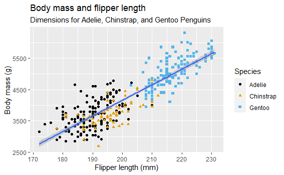

```r
#3

ggplot(
  data=df0,
  mapping=aes(x = flipper_length_mm, y = body_mass_g)
) +
  geom_point(mapping = aes(color = species, shape = species)) +
  geom_smooth(method = "lm") +
  labs(
    title = "Body mass and flipper length",
    subtitle = "Dimensions for Adelie, Chinstrap, and Gentoo Penguins",
    x = "Flipper length (mm)", y = "Body mass (g)", color = "Species", shape = "Species") +
  scale_color_colorblind()
```

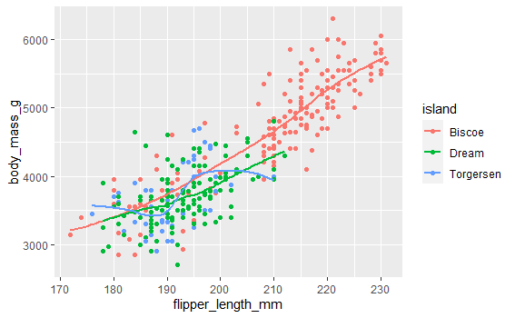

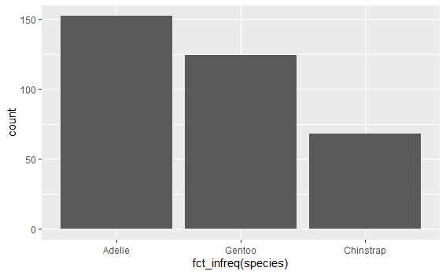

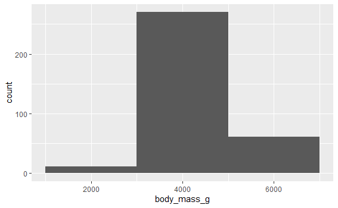

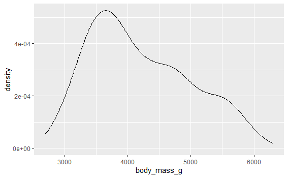

Make a bar plot of species of penguins, where you assign species to the y aesthetic. How is this plot different?

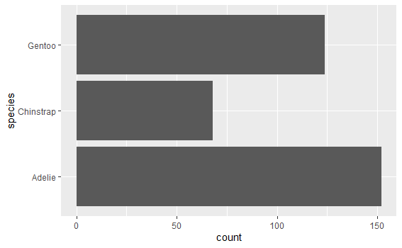

How are the following two plots different? Which aesthetic, color or fill, is more useful for changing the color of bars? R: Fill is more usefull ok

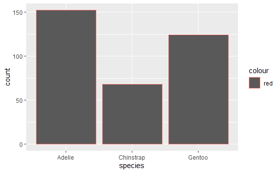

```r
ggplot(penguins, aes(x = species, color = "red")) +
  geom_bar()
```

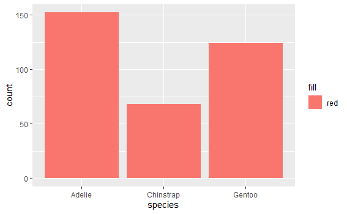

```r
ggplot(penguins, aes(x = species, fill = "red")) +
  geom_bar()
```

3. What does the bins argument in geom_histogram()? Set the number of bins

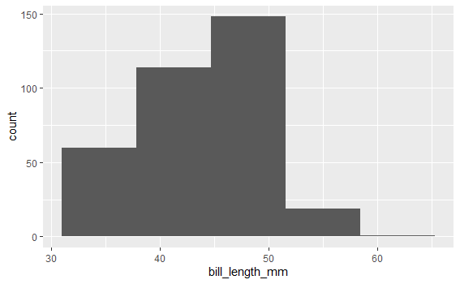

4. Make a histogram of the carat variable in the diamonds dataset that is available when ou load the tidyverse package.Experiment with different binwidth values. What value reveals the most interesint patterns?

R: 0.4 show a decreasing pattern.

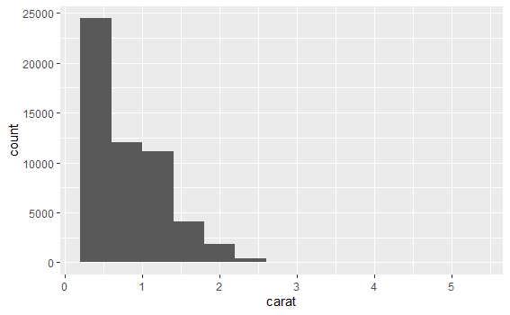

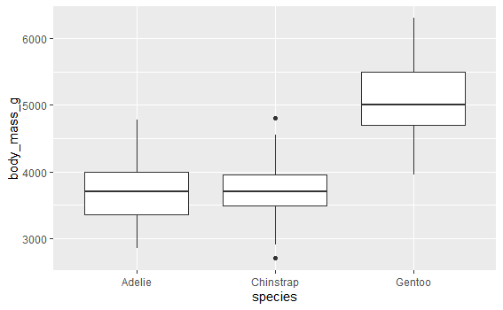

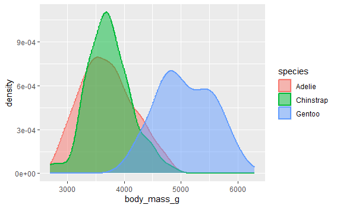

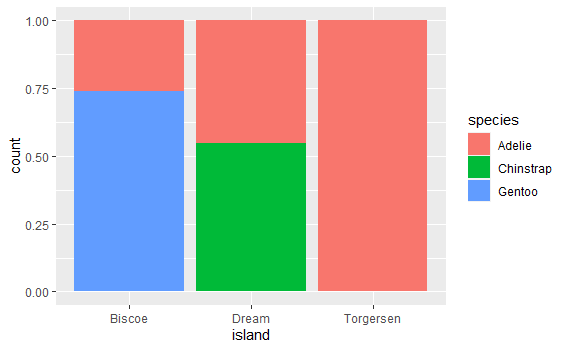

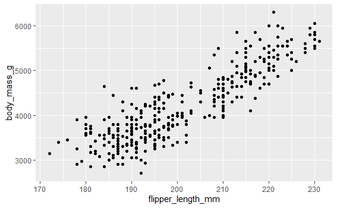

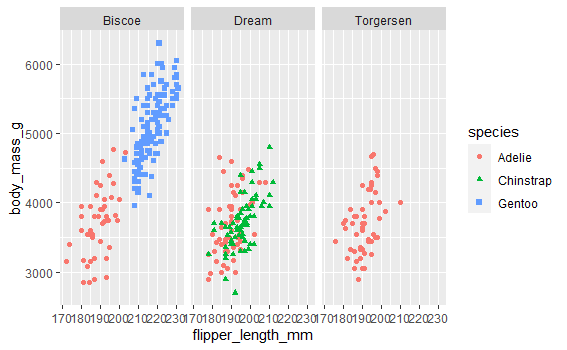

1. The mpg data frame that is bundled with the ggplot2 package contains 234 observations collected by the US Environmental Protection Agency on 38 car models. Which variables in mpg are categorical? Which variables are numerical? (Hint: Type ?mpg to read the documentation for the dataset.) How can you see this information when you run mpg? manufacturer, model, trans, drv, fl and class are categorical whereas the remaining are numeric.

```r
str(mpg)
```

```
tibble [234 × 11] (S3: tbl_df/tbl/data.frame)
 $ manufacturer: chr [1:234] "audi" "audi" "audi" "audi" ...
 $ model       : chr [1:234] "a4" "a4" "a4" "a4" ...
 $ displ       : num [1:234] 1.8 1.8 2 2 2.8 2.8 3.1 1.8 1.8 2 ...
 $ year        : int [1:234] 1999 1999 2008 2008 1999 1999 2008 1999 1999 2008 ...
 $ cyl         : int [1:234] 4 4 4 4 6 6 6 4 4 4 ...
 $ trans       : chr [1:234] "auto(l5)" "manual(m5)" "manual(m6)" "auto(av)" ...
 $ drv         : chr [1:234] "f" "f" "f" "f" ...
 $ cty         : int [1:234] 18 21 20 21 16 18 18 18 16 20 ...
 $ hwy         : int [1:234] 29 29 31 30 26 26 27 26 25 28 ...
 $ fl          : chr [1:234] "p" "p" "p" "p" ...
 $ class       : chr [1:234] "compact" "compact" "compact" "compact" ...
```

2. Make a scatterplot of hwy versus displ using the mpg data frame. Next, map a third, numerical variable to color, then size, then both color and size, and then shape. How do these aesthetics behave differently for categorical versus numerical variables?

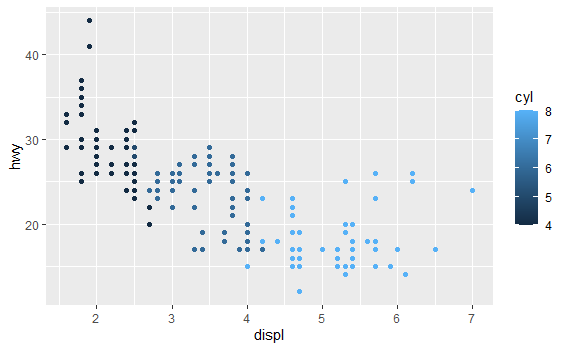

3. In the scatterplot of hwy versus displ, what happens if you map a third variable to linewidth? R: Error, it is not possible to map linewidth

[figure not shown]

```r
ggplot(mpg, aes(y=hwy, x=displ)) +
  geom_point( linewidth=year )
```

4. What happens if you map the same variable to multiple aesthetics?

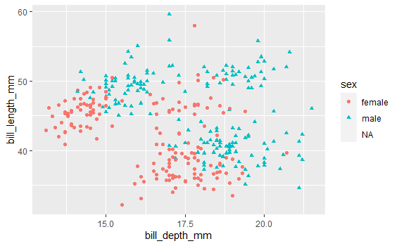

5. Make a scatterplot of bill_depth_mm versus bill_length_mm and color the points by species. What does adding coloring by species reveal about the relationship between these two variables? What about faceting by species? R: coloring reveals that they are wuite different regarding bill measures. Faceting give us better vision of that.

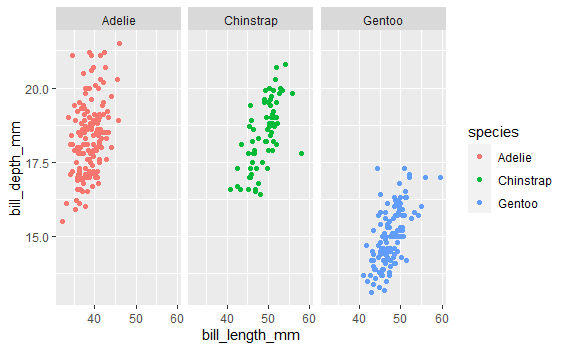

6. Why does the following yield two separate legends? How would you fix it to combine the two legends? By removing the labs argument it is possible to combine both legends into one.

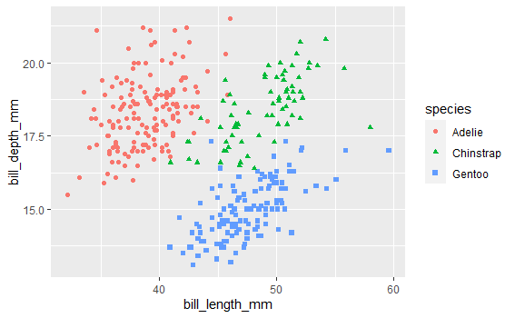

```r
ggsave(filename = "pinguizim.png")
```

```r
ggsave("mpg-plot.pdf")
```

```r
seq(3,6)
```

```
[1] 3 4 5 6
```